# A Modular Computational Framework for Section 2 Voting Rights Act Analysis

Alicia Guerra, Illinois Institute of Technology[^1]

Spring 2026 SoReMo Fellowship Project Final Technical Report

[Back to journal](https://soremo.library.iit.edu)

# Abstract

This paper introduces a modular computational framework for $\S$ 2 Voting Rights Act analysis integrating redistricting data engineering, Bayesian ecological inference, and ensemble-based exact inference into a unified pipeline. The framework propagates posterior uncertainty from the ecological inference stage through plan-level minority opportunity scoring and evaluates enacted district plans against legally constrained alternative plans generated via recombination Markov chains. To avoid unverifiable convergence assumptions associated with long-run Markov chain Monte Carlo sampling, the framework adopts the Besag-Clifford parallel construction, yielding exact finite-sample p-values under kernel reversibility without requiring convergence to stationarity. A probabilistic minority opportunity functional is introduced and characterized axiomatically as the unique district-additive expected opportunity score satisfying a collection of structural assumptions. In a case study of Texas PLANC2333, the enacted plan systematically underperforms neutral alternatives for Black, Latino, and best-group minority opportunity, with exact p-values at or near the finite-sample resolution floor.

# 1 Introduction

Redistricting determines how voters are grouped into electoral districts and therefore shapes the translation of votes into representation.

## 1.1 Redistricting

Redistricting refers to the periodic redrawing of geographic boundaries that define electoral districts. Because most legislative bodies in democratic systems are comprised of elected representatives from specified constituencies, the lines that split up the districts determine which voters are grouped together, which communities share electoral representation, and which candidates and parties prevail in elections (Cain 1985).

## 1.2 The Redistricting Process in the United States

Article I, Section 2 of the U.S. Constitution specifies how seats are apportioned in the House of Representatives among the states (United States 1787). After the decennial U.S. census and apportionment is conducted, states usually initiate their redistricting processes, during which they formulate district boundaries accounting for population changes that occurred during the past decade (Eckman and Whitaker 2025). Although redistricting processes are mostly determined by state laws, congressional district maps are required to comply with the U.S. Constitution and federal law (Eckman and Whitaker 2025).

Since the 1964 Wesberry v. Sanders decision, the U.S. Supreme Court has interpreted the Constitution as mandating that every congressional district possess approximately the same number of people (Eckman and Whitaker 2025). The population totals are obtained from the U.S. Census; today, all congressional districts in a state have a population difference of zero or at most one (Duchin and Walch 2022).

Furthermore, the majority of states require that congressional districts be compact and contiguous — that is, that their districts be reasonably shaped and have all their portions be geographically connected, respectively (Duchin and Walch 2022). Although not all states explicitly require compactness and contiguity in their constitutions, this is considered “standard practice” (DeFord et al. 2021). The U.S. Supreme Court treats compactness and contiguity as traditional redistricting principles and diagnostic signals in racial gerrymandering analysis. For instance, in cases such as Shaw v. Reno (Supreme Court of the United States 1993), Miller v. Johnson (Supreme Court of the United States 1995), and Bush v. Vera (Supreme Court of the United States 1996), lack of compactness and contiguity were cited as evidence of race predominantly determining district lines, which is required to prove racial gerrymandering in violation of the Fourteenth Amendment.

Additionally, although most states do not have a strict prohibition on splitting counties, avoiding county splitting is also considered a standard practice in redistricting (Duchin and Walch 2022).

## 1.3 Gerrymandering

Gerrymandering is a tactic that has been interwoven with United States politics since at least 1812, which is when the term was first coined (Sauer 1992). In simplest terms, gerrymandering can be defined as the manipulation of election district maps to either favor or disfavor a group of people (i.e. a political party, a racial/ethnic group, a socioeconomic class, etc).

## 1.4 Negative Racial Gerrymandering

Negative racial gerrymandering dilutes minority voting power by engineering districts in which minority ballots systematically matter less. Although minority voters retain the formal right to vote, they lack proportional influence.

Unfortunately, this practice has materialized throughout U.S. history. For instance, in response to black Americans obtaining the right to vote in 1870, Reconstruction-era Redeemer Southern Democrats wielded negative racial gerrymandering to preserve white supremacy and curtail black political power (Valelly 2004).

This distortion produces legislatures that are less representative — often whiter and more ideologically extreme than the electorate — and weakens elected officials’ incentives to respond to minority interests.

By breaking the link between voting and representation, negative racial gerrymandering undermines democratic legitimacy, erodes trust, and contributes to lower turnout and political disengagement.

## 1.5 The Legality of Negative Racial Gerrymandering

Negative racial gerrymandering is illegal in the United States by virtue of the Equal Protection Clause of the Fourteenth Amendment and §2 of the Voting Rights Act (VRA).

The Equal Protection Clause of the Fourteenth Amendment forbids denying anyone of “equal protection of the laws” (United States Congress 1868).

§2 of the Voting Rights Act of 1965 precludes states and political entities from wielding any “standard, practice, or procedure” to curtail the voting rights of any U.S. citizen based on race (United States Congress 1965). In the 1986 case of Thornburg v. Gingles, it was ruled that a North Carolina redistricting plan was in violation of §2 of the Voting Rights Act for engaging in negative racial gerrymandering practices — more specifically, of diluting the votes of black citizens (Supreme Court of the United States 1986). This landmark Supreme Court case decided that minority voters can legally challenge negative racial gerrymandering practices in redistricting plans on the grounds of violating §2 of the Voting Rights Act, but that the burden of proof is on them to demonstrate that their capacity to elect their preferred candidates is undermined (Supreme Court of the United States 1986).

In the Thornburg v. Gingles case, the Supreme Court established a framework for minority voters to be able to prove negative racial gerrymandering in violation of §2 of the Voting Rights Act in a court of law (Supreme Court of the United States 1986). Under this framework, plaintiffs must be able to prove the following: (1) a “geographically insular” minority group makes up the majority population of a district, (2) the minority group is “politically cohesive”, and (3) the “bloc voting majority” is usually able to defeat the minority group’s preferred candidates (Supreme Court of the United States 1986). The second and third preconditions are stated by the U.S. Supreme Court as concerning “racially polarized voting” (Supreme Court of the United States 2023).

The U.S. Supreme Court refers to this framework as “the Gingles framework” (Supreme Court of the United States 2023). For the last 40 years, claims of negative racial gerrymandering in violation of §2 of the Voting Rights Act have been assessed via the Gingles framework (Supreme Court of the United States 2023). In the 2023 Allen v. Milligan decision, the U.S. Supreme Court reaffirmed its validity (Supreme Court of the United States 2023).

## 1.6 Current Mid-Decade Redistricting Efforts

Recent mid-decade redistricting efforts make these legal and statistical questions especially timely. Starting in 2025, a coordinated wave of mid-decade redistricting efforts has emerged. The Congressional Research Service has documented that lawmakers in California, Missouri, North Carolina, Ohio, Texas, and Utah enacted new congressional maps ahead of the 2026 midterm elections, with additional states actively considering following in their footsteps (Eckman and Whitaker 2025). California voters approved Proposition 50 in November 2025, establishing new congressional districts for the 2026, 2028, and 2030 elections; federal courts declined to block those maps before the 2026 election cycle (Voting Rights Lab 2026). Missouri enacted a new congressional plan during a 2025 special session, and North Carolina adopted a new congressional map in October 2025 (Voting Rights Lab 2026). Ohio adopted a bipartisan congressional map in October 2025 after earlier litigation over its post-2020 maps (Voting Rights Lab 2026). Utah’s map change followed state-court litigation over partisan gerrymandering and the implementation of a plaintiff-submitted map for the 2026 election cycle (Voting Rights Lab 2026).

Texas initiated one of the most visible and contested episodes in this wave. Reacting to pressure from the Trump administration to expand the Republican congressional delegation, the Texas Legislature convened a special session and, following a House Democratic quorum break, enacted a map (PLANC2333) expected to flip 5 congressional seats from Democrat to Republican (Goodman 2025). Texas’ plan faced so many accusations of negative racial gerrymandering that this escalated to the U.S. Supreme Court in LULAC v. Abbott (Supreme Court of the United States 2025a). It should be noted, however, that when the U.S. Supreme Court issued a stay order for the case, the Texas map was permitted to be enacted into law (Supreme Court of the United States 2025b).

Because PLANC2333 sits at the intersection of mid-decade redistricting, racial vote-dilution allegations, and urgent litigation over the 2026 election cycle, it provides a useful case study for evaluating whether computational methods can measure minority electoral opportunity under a contested enacted plan.

## 1.7 Research Question and Significance

This paper studies how computational methods can help evaluate whether a redistricting plan gives minority voters a fair opportunity to elect their preferred candidates. The central problem is that minority vote dilution is not directly observable from district boundaries alone: it requires combining demographic data, election returns, estimates of racial voting behavior, and comparisons to legally plausible alternative maps. We focus on the 2025 Texas congressional plan (PLANC2333) as a case study. Our goal is to build a transparent pipeline that turns these inputs into statistically interpretable evidence about minority electoral opportunity.

More specifically, the paper asks the following question: given an enacted congressional district plan, can we determine — with statistically valid, finite-sample inference and explicit propagation of voter-behavior uncertainty — whether that plan provides fewer minority opportunity districts than legally compliant alternatives would? Answering this requires three ingredients that have never been combined into a single end-to-end pipeline: harmonized precinct-level demographic and electoral data, an ecological inference (EI) step whose posterior uncertainty is preserved rather than collapsed to point estimates, and an inferential test that does not rest on unverifiable Markov chain convergence assumptions. The framework introduced in this paper supplies all three. This matters because §2 litigation increasingly turns on quantitative evidence, and the credibility of that evidence depends on whether each statistical step — from census-block citizenship estimation to the final $p$-value — can be defended against a hostile cross-examination.

# 2 Related Work

This section reviews prior work in each of the three layers that the framework integrates: redistricting data preparation (Section 2.1), ecological inference (Section 2.2), and ensemble-based outlier analysis (Section 2.3). Section 2.4 then states which methods from this literature are adopted in this paper and why.

## 2.1 Redistricting Data Preparation

This subsection summarizes the conventions adopted from the Data and Democracy Lab for constructing demographic categories and estimating census-block citizen voting age population (CVAP). These conventions are applied directly in the data engineering layer described in Section 4.1.

Their convention for categorizing racial groups involves adopting these group names in the ensuing order: Black, Hispanic, Asian, American Indian (AMIN), Other, and White (Donnay, M. and Duchin, M. and Rock, P. n.d.).

It is emphasized that anyone who identifies as Black should be grouped into the Black population (Donnay, M. and Duchin, M. and Rock, P. n.d.). In other words, the Black population should encompass those who are “Any-Part Black” or “Black Alone or in Combination,” as opposed to just “Black Alone” or “Single-Race Black” (Donnay, M. and Duchin, M. and Rock, P. n.d.).

Then, of the individuals left, the Hispanic population must encompass all individuals who identify as Hispanic in the same way the Black population does (Donnay, M. and Duchin, M. and Rock, P. n.d.). Next, of those left, the Asian population should capture all who identify as Asian or Native Hawaiian Pacific Islander, so as to represent an Asian American Pacific Islander (AAPI) category (Donnay, M. and Duchin, M. and Rock, P. n.d.). Finally, the same logic is used to construct the AMIN, Other, and White categories (Donnay, M. and Duchin, M. and Rock, P. n.d.).

Thereafter, the Decennial Census Public Law 94-171 Redistricting Dataset (PL 94-171; abbreviated as $PL$ in Equations(1) and (2)) is leveraged to generate voting age population (VAP) as sums of census variables (Donnay, M. and Duchin, M. and Rock, P. n.d.).

Subsequently, the CVAP by Race and Ethnicity, a special tabulation from the 5-year American Community Survey (ACS), is analyzed. The problem is that CVAP data from the ACS must be analyzed at the census block level because the base unit of the Decennial Census PL 94-171 data is the census block. In the primary tables, the ACS is reported at the census tract level, which presents a problem because that is a significantly higher level of aggregation than the census block (Donnay, M. and Duchin, M. and Rock, P. n.d.).

Fortunately, the Data and Democracy Lab has introduced a solution to this problem called “discounting” (Donnay, M. and Duchin, M. and Rock, P. n.d.). Discounting refers to the usage of the tract-level ACS data to estimate the citizenship rates of racial groups, then applying the discount to the voting age population (Donnay, M. and Duchin, M. and Rock, P. n.d.)..

An example of “discounting” provided by the Data and Democracy Lab is depicted in Equation (1); in this example, block X belongs to tract Y in state Z and Black CVAP (BCVAP) is estimated by taking the citizenship rate for the group in the tract and applying it to the Black VAP (BVAP) in the block (Donnay, M. and Duchin, M. and Rock, P. n.d.).

$$\frac{BCVAP_{ACS}(tract \:
Y)}{BVAP_{ACS}(tract \: Y)} \times BVAP_{PL}(block \: X) = BCVAP(block
\: X) \tag{1}$$

If the denominator in an equation like Equation (1) is too low, then the Data and Democracy Lab proposes a solution like that in Equation (2). This involves swapping in the citizenship rate given that the tract did not allow for a meaningful estimate (Donnay, M. and Duchin, M. and Rock, P. n.d.).

$$\frac{BCVAP_{ACS}(state \:
Z)}{BVAP_{ACS}(state \: Z)} \times BVAP_{PL}(block \: X) = BCVAP(block
\: X) \tag{2}$$

The Data and Democracy Lab acknowledges that this is a “crude fix”, but states that they intend to release a more sophisticated Bayesian method to address this in the future (Donnay, M. and Duchin, M. and Rock, P. n.d.).

## 2.2 Ecological Inference

To reiterate what is stated in Section 1.5, in order to prove a violation of Section 2 of the Voting Rights Act under the Gingles framework, plaintiffs must prove that the majority votes as a bloc to defeat minority-preferred candidates (Supreme Court of the United States 1986). Hence, any framework performing Section 2 Voting Rights Act analysis must encompass identification of minority-preferred political candidates (Becker et al. 2021).

In state election return datasets, vote totals for political candidates are not computed by race, meaning that direct computation of minority-preferred candidates is impossible (Becker et al. 2021). This is where ecological inference (EI) - the de-facto solution for determining racially polarized voting - comes in. After all, EI is widely regarded as “the best and often only hope of making progress” when it comes to extracting clues about individual behavior from group or aggregate-level data (King et al. 2004).

EI (and ecological regression, its simpler predecessor) is considered a “statistical mainstay” in Section 2 Voting Rights Act litigation (Freedman 1999). U.S. Supreme Court redistricting cases in which lower-court findings relying on ecological inference were reviewed and accepted without methodological objection include Allen v. Milligan (Supreme Court of the United States 2023), Alexander v. South Carolina State Conference of the NAACP (Supreme Court of the United States 2024), Cooper v. Harris (Supreme Court of the United States 2017b), Bethune-Hill v. Virginia State Board of Elections (Supreme Court of the United States 2017a), and Abbott v. Perez (Supreme Court of the United States 2018).

It should be noted, however, that in the same way all statistical inference techniques with missing data give way to uncertainty, ecological inference produces “imperfect” and “uncertain” answers (Becker et al. 2021). Hence, it is essential to estimate the error produced by ecological inference techniques and observe how it compounds or cancels out in high-level conclusions (Becker et al. 2021). So, in addition to identifying the minority-preferred candidates, one must specify the confidence measures that the identifications are correct (Becker et al. 2021). To check for minority control of a district and identify preferred candidates for newly proposed districts, the statewide and precinct-level vote estimates by race should be leveraged (Becker et al. 2021).

Becker et al. (Becker et al. 2021) implement a version of King’s ecological inference, specifically the `ei.mD.bayes` function from `eiPack` which is based on the Bayesian hierarchical Dirichlet model for $R \times C$ (row-by-columns; in this case, racial groups by candidates) tables proposed by King et al. in 1999 (King et al. 1999).

For each election, EI is run at the statewide level using precinct-level input tables (Becker et al. 2021). The inputs for each precinct are the row and column sums for the $R \times C$ table of vote counts. The row sums correspond to the precinct’s estimated number of adult citizens in each racial group. The column sums are the precinct’s vote totals for each candidate (Becker et al. 2021).

Each EI run generates a large random sample of estimated vote counts; in order to obtain the statewide estimates, these values are summed across the entire state (Becker et al. 2021). For each racial group, the candidate with the highest average estimated vote total for an election is the preferred candidate (Becker et al. 2021). In order to obtain a measure of confidence that a candidate was correctly identified as the preferred candidate, repeated draws for the EI distribution are obtained and the frequency with which the preferred candidate receives the most votes is recorded (Becker et al. 2021).

## 2.3 Ensemble-Based Outlier Analysis in Redistricting

Recent methods for analyzing and comparing district plans attempt to do so by placing a plan in the context of valid alternatives - that is, those that cut up the same jurisdiction by the same rules and with the structural features of the geography and the pattern of voting held constant (DeFord et al. 2021). These ensembles contain samples from the full space of plans, aiming to help compare a plan’s properties to the range of possible designs (DeFord et al. 2021).

In one powerful application, ensembles have been used to conduct outlier analysis, or to argue that a proposed plan has properties that are extreme relative to the comparison statistics of alternative plans (DeFord et al. 2021). Arguments like this have featured in a string of recent legal challenges to gerrymanders, all of which were successful at the district court or Supreme Court level (DeFord et al. 2021). Outliers have also received significant attention from the U.S. Supreme Court (culminating in Rucho v. Common Cause (U.S. Supreme Court 2019)) (DeFord et al. 2021). Today, ensemble-based outlier analysis has emerged as one of the dominant quantitative tools to evaluate gerrymandering claims in court.

The way ensemble-based outlier analysis works is that an enacted district plan $\pi_0$ is compared against a large sample of alternative plans from a neutral baseline distribution. The relative position of $\pi_0$ within the ensemble is offered as evidence of atypicality. This methodology was introduced by redistricting expert Jowei Chen in the mid-2010s (Chen and Rodden 2013).

### 2.3.1 Recombination Markov Chains

Early implementations of ensemble-based outlier analysis leveraged flip-based Markov chains (DeFord et al. 2021). However, these were discovered to be problematic for several reasons.

In 2021, Daryl DeFord, Moon Duchin, and Justin Solomon set forth recombination (ReCom), a novel family of Markov chains intended for the ensemble generation of alternative redistricting plans (DeFord et al. 2021). ReCom is one of the most widely used engines for district plan ensemble generation in the redistricting space (Becker et al. 2021).

ReCom chains are considered superior to flip chains because they produce more compact districts, whereas flip chains are said to produce “winding, fractal-like districts” (DeFord et al. 2021). Also, ReCom performs much faster than flip because flip can only change the assignment label of a few nodes at a time (DeFord et al. 2021).

The way a ReCom chain works is it proposes whole-district swaps via uniform spanning tree bipartitions of merged and adjacent districts (DeFord et al. 2021).

### 2.3.2 The Mixing Time Problem

Ensemble-based inference tests rely on the premise that the Markov chain has run long enough for the sampled plans to be approximately representative of the target distribution. The validity of any $p$-value derived from a single long chain depends on that premise. Conventional defenses are empirical: running multiple chains from different starting points, comparing summary statistics across chains, and monitoring autocorrelation in test statistics over chain length. These diagnostics are necessary but not sufficient - they cannot certify convergence, and they offer no formal bound on the bias they may fail to detect.

Two prerequisite questions sit beneath the mixing-time question itself. The first is whether the chain is reversible with respect to some well-defined target measure, since reversibility is what guarantees the existence of a unique stationary distribution. The second is whether the target distribution is known, since without it the chain’s draws cannot be assigned interpretable probabilities. Until recently, neither of these questions was settled for ReCom. Cannon et al. (Cannon, Duchin, et al. 2022) resolved the first by constructing a reversible variant of ReCom called Reversible ReCom (RevReCom) whose target measure is the spanning-tree-weighted partition distribution. This is the foundation on which any subsequent mixing-time analysis must be built, and the inferential framework adopted in this paper (Section 4.4) relies on exactly this reversibility property.

Even with reversibility settled, the mixing time of ReCom on real-world precinct graphs remains unknown, and polynomial mixing is conjectured but not proven (Levin et al. 2009; DeFord et al. 2021). A sequence of newer Markov chains has been proposed that retain known target distributions while improving the prospects for a future mixing-time proof. The marked edge walk (MEW) introduced by McWhorter and DeFord (McWhorter and DeFord 2025) operates on the space of spanning trees with marked edges, allowing calculable Metropolis-Hastings transition probabilities under a tunable target distribution and convergence to targets unrelated to spanning trees. The cycle walk introduced by DeFord et al. (DeFord et al. 2025) is a faster successor to MEW: it avoids the redundancy that arises when distinct spanning trees in MEW induce the same partition, walking instead through cycles directly. Most recently, the balanced up-down (BUD) walk introduced by Akitaya et al. (Akitaya et al. 2026) improves on the Cycle Walk and is the most promising candidate to date for a mixing-time proof, although such a proof has not yet been established.

The picture is therefore that reversibility is now resolved for ReCom and several of its successors, target distributions are known for each of the newer walks, and the field is moving toward - but has not yet reached - a rigorous mixing-time bound for any chain in this family. In the meantime, every ensemble-based $p$-value reported from a single long ReCom run remains conditional on the chain having mixed. This concern was raised in Rucho v. Common Cause, where ensemble-based outlier analysis was called into question on convergence grounds (U.S. Supreme Court 2019). The Besag-Clifford parallel construction (Section 4.4) sidesteps the question entirely by yielding exact finite-sample $p$-values under kernel reversibility alone - a property already established by Cannon et al. (Cannon, Duchin, et al. 2022) for the chain used in this paper.

### 2.3.3 Approaches to the Mixing-Time Problem

Three responses to the mixing problem have appeared in the literature.

The most dominant approach in applied work is more compute - that is, longer chains, more starting points, and more elaborate diagnostics. However, this is not a true solution because the result is still not valid unless the chain has mixed, and no amount of empirical convergence diagnostic can rule out a slow-mixing pathology that the diagnostic is not designed to detect.

Cannon et al. (Cannon, Goldbloom-Helzner, et al. 2022) introduced the second approach: short bursts. Short bursts sacrifice ensemble representativeness to optimize over plans satisfying particular criteria (Cannon, Goldbloom-Helzner, et al. 2022). Although short bursts are excellent for detecting extreme plans, they are not intended for inferential testing of an enacted plan against a neutral baseline (Cannon, Goldbloom-Helzner, et al. 2022).

The third approach is to leverage an inferential framework that does not require mixing at all. In 1989, Besag and Clifford (Besag and Clifford 1989) introduced two such frameworks for generalized Monte Carlo significance tests. The first is the serial method, where the test statistic’s null distribution is conducted from a single chain via time-reversal arguments (Besag and Clifford 1989). The second method, the one adopted in this paper, is the parallel method, where independent chains launched from a common state produce an exchangeable ensemble whose ranks are exactly uniform on the null (Besag and Clifford 1989). Neither method requires the chain(s) to have mixed; the only requirement is reversibility of the kernel with respect to the target measure (Besag and Clifford 1989). The methods of Besag and Clifford are well-established in spatial statistics, ecology, and image analysis, but have not been applied to redistricting ensembles.

### 2.3.4 Quantifying Minority Opportunity

The most influential framework for quantifying minority opportunity was introduced by Becker et al (Becker et al. 2021). This approach combines EI to estimate each racial group’s candidate preferences, recency-weighted aggregation across elections to smooth idiosyncratic single-election noise, and confidence-weighted aggregation that downweights elections with diffuse rather than polarized preferences (Becker et al. 2021). The output is a district-level “effectiveness score” $s^g_d \in [0,1]$ which measures the weighted share of recent elections in which racial group $g$’s preferred candidate won (Becker et al. 2021).

This effectiveness score is then thresholded to count “opportunity districts” (Becker et al. 2021). For example, a district is considered to be “Latino effective” if $s^L_d$ exceeds a cutoff (typically 0.5 or 0.6), and the count of such districts is the plan’s opportunity score (Becker et al. 2021). This thresholding step is the pressure point of existing literature. There are two major issues with it. The first is that the threshold is theoretically arbitrary; in other words, there is no principled reason to choose 0.5 over 0.6 or vice versa. The second issue is that the threshold is fragile near the cutoff point. For example, a district with $s^g_d = 0.59$ counts for nothing while a district with $s^g_d = 0.61$ counts in full, even though these two districts are almost identical electorally. This fragility is especially evident in situations when the effectiveness scores cluster near the cutoff.

The natural alternative is to stop thresholding altogether and allow the per-district win probability $p^g_d$ to enter the plan-level function directly: $O_g(\pi) = \sum_d p^g_d(\pi)$, the expected number of districts where racial group $g$’s preferred candidate won. This functional has been informally suggested in the literature, but it has not been adopted as the basis for a formal inferential test.

## 2.4 Methods

The related work detailed in Section 2 above surveys several alternatives at each layer of the pipeline; we now state which ones are adopted here and why. For demographic preparation, we follow the Data and Democracy Lab conventions described in Section 2.1, including their discounting estimator for census-block CVAP, because it is the standard convention used in the redistricting literature and produces outputs at the block level required by downstream geographic crosswalking. For EI, we adopt the multinomial-Dirichlet Bayesian $R \times C$ model of Rosen et al. (Rosen et al. 2001), which is the same model Becker et al. (Becker et al. 2021) use in their Texas analysis; we implement it via the Python package `pyei` (`r_by_c.RowByColumnEI`) rather than R’s `eiPack::ei.MD.bayes` because the rest of the pipeline is in Python. For ensemble generation, we use the ReCom Markov chain of DeFord et al. (DeFord et al. 2021) rather than the older flip chains, because ReCom produces more compact districts and proposes whole-district swaps via spanning-tree bipartitions that respect contiguity by construction. For minority opportunity scoring, we depart from the Becker et al. (Becker et al. 2021) thresholded effectiveness score and adopt the expected-count functional $O_g(\pi) = \sum_d p^g_d(\pi)$, because thresholding is fragile near the cutoff and discards calibrated probability information; we justify the expected-count functional axiomatically in Section 4.3.4. Finally, for the inferential test we adopt parallel construction of Besag-Clifford (Besag and Clifford 1989) rather than a long single-chain ReCom run, because Besag-Clifford yields exact $p$-values under kernel reversibility and does not depend on the chain having mixed. Each of these choices is implemented in a modular fashion so that improvements at one layer do not require rewriting the others.

# 3 Contribution

The contribution of this paper is not a new data source, EI model, or redistricting sampler in isolation, but a framework that connects these components into a coherent inferential pipeline. The components surveyed in Section 2 - redistricting data preparation, $R \times C$ ecological inference, and ensemble generation - exist as separately developed and well-documented tools. Prior work has combined some of these components for Section 2 VRA analysis, but the literature lacks a single end-to-end pipeline that propagates posterior EI uncertainty through plan-level opportunity scoring and concludes with an inferential test that does not depend on Markov chain convergence. This paper makes four specific contributions.

- **[C1] Unified framework.** First, we develop a modular end-to-end framework for §2 VRA analysis. The framework ingests publicly available demographic, geographic, and election data and produces calibrated minority-opportunity probabilities for every district in every plan.
- **[C2] Uncertainty propagation.** Second, we propagate posterior uncertainty from ecological inference into the ensemble-scoring stage. Instead of collapsing racial voting estimates to point estimates, the framework carries forward compressed posterior count quantiles so that plan-level opportunity scores reflect both map variability and voter-behavior uncertainty.
- **[C3] Opportunity functional.** Third, we introduce a probabilistic minority-opportunity functional based on the expected number of districts in which a minority group’s preferred candidate wins. We justify this functional axiomatically and use it as the plan-level statistic for comparing enacted and alternative plans.
- **[C4] Exact finite-sample inference.** Fourth, we adapt the Besag–Clifford parallel construction to the redistricting setting. This yields exact finite-sample p-values under kernel reversibility and avoids relying on unverifiable claims that a long ReCom chain has mixed.

# 4 The Framework

The proposed framework consists of three sequential layers:

- **[L1]** data engineering layer
- **[L2]** ecological inference layer
- **[L3]** ensemble generation and inference layer

Each layer takes the output of the previous one as input. Section 4.1, 4.2, and 4.3 describe each layer in turn, and 4.4 introduces the Besag–Clifford exact inference procedure that the ensemble layer applies in its final step.

The framework begins with the ingestion and harmonization of racial demographic, geographic, and election data in the data engineering layer. Then, the ecological inference layer estimates racial voting behavior and associated uncertainty distributions. Finally, the ensemble generation and inference layer generates legally compliant alternative district plans and evaluates minority opportunity statistics under uncertainty-aware scoring procedures.

## 4.1 Data Engineering Layer

### 4.1.1 Data Sources

The data engineering layer ingests the following raw inputs:

- **[D1]** State District Plan Shapefile,
- **[D2]** Decennial Census PL 94-171 Redistricting Dataset,
- **[D3]** CVAP by Race and Ethnicity in a Special Tabulation from the ACS 5-Year Estimates,
- **[D4]** State Census Blocks Shapefile (TIGER/LINE),
- **[D5]** State Voting Tabulation District (VTD) Shapefile, and
- **[D6]** State VTDs Election Data.

#### 4.1.2 Data Engineering Layer Overview

The ingestion stage standardizes formats and projections. Construction of demographic categories follows the methodology outlined in Section 2.1. A geographic crosswalk allocates blocks to precincts by spatial intersection, after which keys are harmonized across the demographic and electoral sources, the unified dataset is assembled, and a final schema enforces derived proportion columns and consistent column names. Validation checks confirm that population sums match between sources and that no precinct is left without a district assignment.

## 4.2 Ecological Inference Layer

The ecological inference layer takes the consolidated precinct-level dataset produced in Section 4.1 and returns, for every district $d$ under plan $\pi$, a calibrated probability $p^g_d(\pi)$ that racial group $g$’s preferred candidate wins district $d$.

The four steps of the ecological inference pipeline are as follows:

1. multinomial-Dirichlet Bayesian $R \times C$ ecological inference,
2. post-EI processing,
3. construction of a per-district calibration dataset, and
4. logistic calibration of raw opportunity scores.

Steps 1 and 2 propagate posterior uncertainty forward in a compressed form. Steps 3 and 4 anchor the resulting probabilities to observed electoral outcomes on the enacted plan.

### 4.2.1 Multinomial-Dirichlet Bayesian $R \times C$ Ecological Inference

Let precincts be indexed by $p = 1, \ldots, n$, racial groups by $r = 1, \ldots, R$, and candidates by $c = 1, \ldots, C$.

Let $V_p$ denote the vector of observed vote counts in each precinct $p$, with the total count being $N_p$. Let $\theta_p$ represent the candidate support probabilities in precinct $p$. Note that in the context of EI, $\theta_p$ is not directly observed and must be inferred from demographic and electoral data (King 1997).

Following the multinomial-Dirichlet EI framework of Rosen et al. (Rosen et al. 2001), precinct-level vote counts are modeled using the likelihood $V_p \sim \mathrm{Multinomial}(N_p, \theta_p)$. Note that this is the exact same model implemented by Becker et al. (Becker et al. 2021), with the main difference being that their model is implemented in `eiPack`’s `ei.MD.bayes`, while this one is implemented in its Python equivalent, `pyei.r_by_c.RowByColumnEI`.

Also note that the multinomial-Dirichlet Bayesian $R \times C$ EI stage takes in four inputs:

1. the consolidated precinct-level dataset generated in Section 4.1,
2. election specifications,
3. recency weights that downweight older contests, and
4. a list of elections dropped for data quality reasons.

The posterior is summarized in three artifacts:

1. a statewide preferences record, the posterior probability that a candidate is the group’s preferred candidate statewide;
2. mean vote counts, the posterior-mean number of votes by each group $g$ for every candidate in each precinct $p$; and
3. quantile draws, a discrete grid of posterior quantiles of those precinct-level counts.

The method Becker et al. (Becker et al. 2021) leverage to record precinct-level probabilistic information in a condensed form is adopted here. This method allows distributions to be recorded at every step of the Markov chain and involves compressing a histogram into octiles, storing only eight “bars” as opposed to “dozens or hundreds” (Becker et al. 2021). This strategy reduces storage requirements while preserving approximate uncertainty.

### 4.2.2 Post-EI Processing

The second stage of the EI pipeline, postprocessing, involves pivoting the data from long to wide format to be consumed by the next layer (ensemble generation and inference). Also, EI group labels are mapped to the CVAP column names used in the consolidated precinct-level dataset from Section 4.1, and a table of in-group weights is derived. This in-group weighting tactic is adopted from (Becker et al. 2021) to distinguish between group preferences that are fully, partially, or not aligned with the minority groups of interest. For example, if the preferred candidate is from the minority group of interest, a weight of 1.0 is given (Becker et al. 2021). If the candidate is from one of the relevant minority groups (e.g., Black or Hispanic) but not both, a weight of 0.75 is given (Becker et al. 2021). Otherwise, the candidate is given a weight of 0.5 (Becker et al. 2021). In this case, because a case study on Texas congressional districts is being performed, the minority groups of interest are Black and Latino voters. (Becker et al. 2021) previously did a case study on Texas congressional districts and also chose to focus on Latino and Black voters because “both Latino and Black voters are numerous enough to require VRA attention.”

### 4.2.3 Building Calibration Data

The first two steps in the EI layer generate posterior-driven opportunity scores that are uncalibrated. Here, the enacted district plan $\pi_0$ is scored.

For each district $d$ in the enacted plan $\pi_0$ and for each racial group $g$ and each scoring mode $m$, this step estimates $p^{m,g}_d(\pi_0) \in [0,1]$, the raw uncalibrated probability that group $g$’s preferred candidate won in district $d$. These probabilities are computed using repeated posterior draws combined with election-level aggregation procedures. As in (Becker et al. 2021), these scores are computed in three modes: “statewide” (with statewide preferences applied uniformly), “unweighted” (with equal weighting across elections), and “district” (with district-specific preferences). Fitting all three modes is important because it allows for exposure of sensitivity to the aggregation choice. This step yields calibration data with scores for every district and racial group across all three modes.

### 4.2.4 Generating Logit Parameters

Finally, a logistic calibration step, inspired by Becker et al. (Becker et al. 2021), is performed. Logistic regression has been leveraged as a post-hoc probability calibrator on top of another model’s scores since 1999, when that strategy was introduced (Platt 1999). The purpose of this step, according to (Becker et al. 2021), is to “bolster the probabilistic interpretation of the scores.” For example, a district with a calibrated $p^g_d(\pi)$ score of 0.5 can be interpreted as having a 50/50 win probability for that minority group’s preferred candidate (Becker et al. 2021).

A one-feature logistic regression is fit for each combination of mode (“statewide,” “unweighted,” “district”) and racial group (Becker et al. 2021). As in Becker et al. (Becker et al. 2021), a label of 0 or 1 is applied to each district depending on the observed performance of each district across all the elections held during these plans. Also, as in Becker et al. (Becker et al. 2021), an $\ell_2$ penalty is added and balanced class weights are used to account for class imbalances.

## 4.3 Ensemble Generation & Inference Layer

The ensemble generation and inference layer takes the calibrated district-level win probabilities $p^g_d(\pi)$ produced in Section 4.2 and evaluates whether the enacted plan provides fewer minority opportunity districts than a neutral baseline. The pipeline takes in four inputs: the precinct data produced in Section 4.1, the demographic values for each precinct, the EI outputs (preferences, mean counts, count quantiles, in-group weights, logit parameters), and election data. A null distribution of alternative plans is then generated from a ReCom Markov chain with legal constraints. Next, canonical, diversity-calibrated, and best-group minority opportunity scores are calculated for each plan. The third and final step in the layer involves applying a Besag–Clifford parallel construction to convert the scored plan ensemble into an exact $p$-value for the null hypothesis that the enacted plan is typical under the null.

### 4.3.1 Setup and Notation

The notation of DeFord et al. (DeFord et al. 2021) is adopted here. A rook adjacency graph $G = (V, E)$ is constructed where $V$ is a set of vertices for each geographic unit (precincts, in this case) and $E$ is a set of edges between geographically adjacent units (DeFord et al. 2021). A redistricting plan is an assignment of each node to one of $K$ districts via a labeling map $V \to \{1, \ldots, K\}$ (DeFord et al. 2021). Consistent with the notation in Section 4.2, the enacted plan is denoted $\pi_0$.

As stated by (DeFord et al. 2021), in dual graphs derived from real-world data, nodes are weighted with populations or demographic data, represented by functions $w : V \to \mathbb{R}$. Hence, each precinct carries a population weight $w(v)$ (DeFord et al. 2021) from the consolidated precinct-level dataset generated in Section 4.1. Let $\epsilon > 0$ be a small population deviation tolerance (Cannon, Duchin, et al. 2022).

A condition that bounds population deviation can be modeled as

$$(1 - \epsilon) \frac{\sum_V w(v)}{K} \le
|V_i| \le (1 + \epsilon) \frac{\sum_V w(v)}{K}
\tag{3}$$
(DeFord et al. 2021).

Let $\Pi_K(\epsilon)$ denote the set of redistricting plans where every district induces a connected subgraph and the population balance condition holds for every district $d$. The recombination measure on $\Pi_K(\epsilon)$ is the spanning tree measure

$$\rho(\pi) \propto \prod_{d=1}^{K}
\tau\bigl(G[\pi^{-1}(d)]\bigr), \tag{4}$$

where $\tau(H)$ is the number of spanning trees of subgraph $H$ (DeFord et al. 2025).

### 4.3.2 The Neutral Ensemble: ReCom with Legal Constraints

The null distribution is generated by a ReCom Markov chain on $\Pi_K(\epsilon)$. As stated in Section 2.3, ReCom proposes whole-district swaps by merging two adjacent districts, drawing a uniform spanning tree of the merged subgraph, and bipartitioning that tree along an edge whose removal yields two connected subgraphs of population within $\epsilon$ of $\bar{w}$ (DeFord et al. 2021). The kernel is reversible with respect to $\rho$.

The hypothesis being tested is

$$H_0 : \pi_0 \sim \rho_C,
\tag{5}$$

where $\rho_C$ is $\rho$ restricted to a constraint subset $C \subseteq \Pi_K(\epsilon)$ (DeFord et al. 2021).

#### Constraints

To reiterate Section 1.2, redistricting plans are required to adhere to certain legal constraints including population balance, contiguity, compactness, and avoiding county splitting. The population balance constraint has been addressed in the previous subsection.

With regard to contiguity, although a hard contiguity constraint was not added to the pipeline, ReCom’s spanning tree mechanism guarantees that every accepted proposal is contiguous by construction (DeFord et al. 2021).

To address compactness, (DeFord et al. 2021) suggest that a “mathematically natural manner” for handling compactness in a discrete model is counting the number of cut edges in a district plan; cut edges refer to the number of edges in the dual graph whose endpoints belong to different districts. This is intended to provide a discrete perimeter of the plan, as it corresponds well to informal visual standards of common district shapes (DeFord et al. 2021).

Let

$$\mathrm{CE}(\pi) = |\{e \in E : \pi(u)
\ne \pi(w) \text{ for } e = \{u, w\}\}| \tag{6}$$

represent the number of total cut edges in the district plan (DeFord et al. 2021). We impose

$$\mathrm{CE}(\pi) \le s_c \cdot
\mathrm{CE}(\pi_0), \quad s_c = 1.5. \tag{7}$$

Scaling the threshold to $\pi_0$ rather than an absolute number makes the constraint state-relative; alternative plans must not be less compact than the enacted plan up to the slack $s_c$.

To enforce the county-splitting prevention constraint, let $\mathrm{CS}(\pi)$ denote the number of counties whose precincts span two or more districts. We impose

$$\mathrm{CS}(\pi) \le s_g \cdot
\mathrm{CS}(\pi_0), \quad s_g = 1.2, \tag{8}$$

again scaled to the enacted plan $\pi_0$.

#### Mixing Time

Section 2.3.2 reviews the status of the mixing-time problem for ReCom and its successors: reversibility has been established (Cannon, Duchin, et al. 2022), several newer chains (MEW, Cycle Walk, BUD) have known target distributions and improve the prospects for a future mixing-time proof, but no chain in this family has a proven polynomial mixing time on realistic precinct graphs. Any inference procedure that relies on a single long chain having converged to $\rho_C$ therefore inherits an unverifiable convergence assumption. The framework sidesteps this concern by adopting the Besag–Clifford parallel construction (Section 4.4): validity holds under kernel reversibility alone, which is already established for the chain used here.

### 4.3.3 Opportunity Scores

#### Canonical Minority Opportunity Functional

For each protected minority group $g$, each plan $\pi$, and each district $d$, let $p^g_d(\pi) \in [0,1]$ denote the model-based probability that group $g$’s preferred candidate wins in district $d$. These probabilities have already been computed in the EI layer.

The minority opportunity functional is defined as the sum of district-level win probabilities:

$$O_g(\pi) = \sum_{d=1}^{K} p^g_d(\pi).
\tag{9}$$

Related expected-opportunity formulations have appeared informally in prior redistricting literature, although not as the basis for an exact inferential framework.

#### Best-Group Opportunity Functional

To model a combined best-group opportunity between two racial minority groups (in this case, Black voters $B$ and Latino voters $L$), let

$$O_{\mathrm{joint}}(\pi) = \sum_{d=1}^{K}
\max\bigl\{p^B_d(\pi), p^L_d(\pi)\bigr\}. \tag{10}$$

The coalition functional credits each district to the coalition group with the higher estimated win probability.

#### Diversity-Calibrated Opportunity Functional

Let $\bar{m}_g$ denote the statewide CVAP share of racial minority group $g$, and define the diversity-calibrated minority opportunity functional $F_g$ as

$$F_g(\pi) = O_g(\pi) - K \bar{m}_g.
\tag{11}$$

This functional centers minority opportunity relative to statewide demographic representation. It is important to state that the diversity-calibrated opportunity functional is not intended to define a legal entitlement to proportional representation; instead, it is intended to provide a normalized descriptive benchmark to facilitate interstate comparison. Demographics differ across states — for instance, there is much more diversity in California than in North Dakota.

### 4.3.4 Axiomatic Justification of the Minority Opportunity Functional

The minority opportunity functional $O_g(\pi) = \sum_d p^g_d(\pi)$ is not merely a heuristic choice among many. The five structural axioms below motivate the expected minority opportunity functional. Assume that the plan-level minority opportunity depends solely on the vector of district-level preferred candidate win probabilities $\mathbf{p}(\pi) = (p^g_1(\pi), \ldots, p^g_K(\pi))$.

The five axioms then constrain $f$:

|  | Axiom | Statement | Intuition |
| --- | --- | --- | --- |
| Axiom 1 | Symmetry | $f$ is invariant under permutations of its arguments. | District labels carry no information; only the multiset of probabilities matters. |
| Axiom 2 | District Additivity | $f(p_1, \ldots, p_K) = \sum_{d=1}^K \phi_d(p_d)$ for some $\phi_d : [0,1] \to \mathbb{R}$. | A district’s contribution does not depend on what happens in other districts. |
| Axiom 3 | Monotonicity | If $p_d \le p'_d$ for all $d$, then $f(\mathbf{p}) \le f(\mathbf{p}')$. | Higher win probabilities cannot decrease minority opportunity. |
| Axiom 4 | Normalization | $f(\mathbf{0}) = 0$ and $f(\mathbf{1}) = K$. | A plan that wins nowhere scores 0; a plan that wins everywhere scores $K$. |
| Axiom 5 | Expected-Count Interpretation | If district outcomes are independent $\mathrm{Bernoulli}(p_d)$, then $f(\mathbf{p})$ equals the expected number of districts in which group $g$’s preferred candidate wins. | $f$ is the probabilistic count of opportunity districts. |

*Table 1: The five structural axioms.* **Theorem 1 (Characterization).** A function $f : [0,1]^K \to \mathbb{R}$ satisfies Axioms 1–5 if and only if
$$f(p_1, \ldots, p_K) = \sum_{d=1}^{K}
p_d.$$

**Proof.** The sum $\sum_d p_d$ is plainly symmetric, additive across coordinates, weakly increasing in each $p_d$, evaluates to 0 at $\mathbf{p} = \mathbf{0}$ and to $K$ at $\mathbf{p} = \mathbf{1}$, and equals $\mathbb{E}\bigl[\sum_d X_d\bigr]$ when $X_d \sim \mathrm{Bernoulli}(p_d)$ independently. So, Axioms 1–5 all hold.

For the converse, suppose $f$ satisfies Axioms 1–5. Axiom 2 gives $f(\mathbf{p}) = \sum_d \phi_d(p_d)$ for some component functions $\phi_1, \ldots, \phi_K$. Axiom 1 then forces $\phi_1 = \phi_2 = \cdots = \phi_K$. Call this common function $\phi$, so $f(\mathbf{p}) = \sum_d \phi(p_d)$. Axiom 4 at $\mathbf{p} = \mathbf{0}$ gives $K \phi(0) = 0$, hence $\phi(0) = 0$; at $\mathbf{p} = \mathbf{1}$, $K \phi(1) = K$, hence $\phi(1) = 1$. Axiom 3 forces $\phi$ to be weakly increasing. Axiom 5 says $\sum_d \phi(p_d) = \sum_d p_d$ for every $\mathbf{p} \in [0,1]^K$. Setting $\mathbf{p} = (p, 0, \ldots, 0)$ and using $\phi(0) = 0$ gives $\phi(p) = p$ for every $p \in [0,1]$. Hence $f(\mathbf{p}) = \sum_d p_d$. $\square$

To be completely transparent, Axiom 5 is intentionally strong and encodes an expected-count interpretation of minority opportunity. Also, the characterization result should not be interpreted as proving that alternative opportunity functionals are invalid or unusable. Rather, it demonstrates that under the particular structural assumptions encoded by Axioms 1–5, the expected-count functional arises naturally.

## 4.4 Besag-Clifford Exact Inference

Conventional ReCom analyses report tail-rank statistics from a single long chain and rely on convergence diagnostics to defend their validity (DeFord et al. 2021). Here, the parallel method introduced by Besag and Clifford (Besag and Clifford 1989) - also referred to as “the hub-and-spoke sampler” (Barber and Janson 2022) - is adopted and yields exact $p$-values under $H_0$ regardless of the kernel’s mixing time.

Let $K(\cdot, \cdot)$ denote a Markov kernel that is reversible with respect to the target measure $\rho_C$. The parallel construction proceeds as follows:

1. **Reverse walk to a hub.** Starting from the data point $\pi_0$, run the chain backward (equivalently, forward, by reversibility) for $k$ steps to reach a hub state $X^*$.
2. **Forward walks to spokes.** From the hub $X^*$, run $M$ independent forward chains for $k$ steps each, producing spokes $Y^{(1)}, Y^{(2)}, \ldots, Y^{(M)}$.

Under reversibility of the kernel and $H_0 : \pi_0 \sim \rho_C$, the collection
$$\bigl(\pi_0, Y^{(1)}, Y^{(2)}, \ldots, Y^{(M)}\bigr)$$
is exchangeable. Consequently, the rank of any test statistic $T$ evaluated on $\pi_0$ within this collection is uniformly distributed on $\{1, 2, \ldots, M + 1\}$ under the null.

For a one-sided test in which small values of $T$ constitute evidence against $H_0$ (the relevant direction for $T = F_g$, where dilution corresponds to small values), the exact $p$-value is

$$p = \frac{\bigl|\{j : T(Y^{(j)}) \le
T(\pi_0)\}\bigr| + 1}{M + 1}. \tag{12}$$

The minimum achievable $p$-value, attained when $T(\pi_0)$ is strictly less than $T$ on every spoke, is $1/(M + 1)$. With $M = 1000$, this resolution floor is approximately $10^{-3}$.

This procedure requires only reversibility of the kernel with respect to $\rho_C$; it does not require the chain to have mixed.

# 5 Case Study: Texas Congressional Districts

The case study below applies the framework of Section 4 end-to-end to the Texas PLANC2333 congressional plan enacted in 2025. Every result reported in this section - the demographic shares in Table 2, the racially polarized voting estimates in Figures 1 and 2, the Besag-Clifford null distributions in Figures 3 and 4, and the precinct-level opportunity heatmaps in Figures 5 and 6 - is produced by running the three-layer pipeline (data engineering, ecological inference, ensemble generation and inference) on publicly available raw inputs with no manual intervention between layers. The purpose of the case study is twofold: to demonstrate that the framework runs end-to-end on a real, contested redistricting plan, and to provide a substantive test of whether the enacted Texas plan systematically underperforms neutral alternatives with respect to minority electoral opportunity.

Relative to prior Texas redistricting analyses, the point of this case study is not merely to show that Texas contains racially polarized voting or that alternative maps can be generated; rather, it demonstrates that posterior EI uncertainty, probabilistic opportunity scoring, and exact finite-sample ensemble comparison can be combined in a single reproducible workflow.

To our knowledge, no peer-reviewed article currently performs a Section 2 VRA analysis on Texas’ PLANC2333, likely because the plan was enacted so recently. However, redistricting expert Moon Duchin provided a report on PLANC2333 which is available in the Supreme Court Appendix (Texas State Conference of the NAACP 2025), and her findings corroborate the direction of this paper’s results. Both analyses find that PLANC2333 is an extreme outlier relative to alternative plans. The main difference between our works is that Duchin’s report emphasizes racial composition and intent-relevant anomalies (Texas State Conference of the NAACP 2025), whereas this paper emphasizes minority electoral opportunity and exact finite-sample inference. Taken together, these findings provide evidence that PLANC2333’s treatment of minority voters is difficult to explain by ordinary race-neutral redistricting variation alone.

## 5.1 Data Engineering Layer Implementation

The raw inputs are: - **[D1]** Texas PLANC2333 District Plan Shapefile - **[D2]** Decennial Census PL 94-171 Redistricting Dataset, - **[D3]** CVAP by Race and Ethnicity in a Special Tabulation from the ACS 5-Year Estimates, - **[D4]** Texas Census Blocks Shapefile (TIGER/LINE), - **[D5]** Texas VTDs Shapefile, and - **[D6]** State VTDs Election Data.

Table 2 summarizes the resulting statewide demographic shares.

| Racial Group | Share of Total Population | Share of VAP | Share of CVAP |
| --- | --- | --- | --- |
| Hispanic | 34.7% | 35.6% | 32.6% |
| Black | 13.5% | 13.0% | 12.9% |
| White | 46.2% | 43.2% | 48.9% |
| Asian | 5.0% | 6.1% | 4.8% |
| American Indian | 0.7% | 1.3% | 0.7% |
| *Total Count* | 29,145,505 | 21,866,700 | 18,252,793 |

*Table 2: Texas Demographics. Statewide demographic shares of Texas residents by total population, voting-age population (VAP), and citizen voting-age population (CVAP). Total population and VAP data are taken from the 2020 decennial census, while CVAP data come from the American Community Survey (ACS) five-year rolling average ending in 2024.*

As shown in Table 3, the election inventory comprises six 2024 statewide contests.

Although Texas congressional districts are the ones being assessed for Section 2 VRA violations in this case study, the analysis is based on statewide elections. This is a common practice in redistricting analysis; the problem with including congressional elections in the inventory is that it is unclear how votes for one congressional candidate would transfer to votes for a different candidate (Becker et al. 2021). By leveraging statewide elections instead of local elections, “apples-to-apples” comparisons across different regions of the state can be made; after all, the same set of candidates competed everywhere in the state (Becker et al. 2021).

When performing Section 2 VRA analysis, it is optimal to include data from the past ten years (Becker et al. 2021). However, it is not always possible to meet this ideal due to data availability and precinct instability (Becker et al. 2021). Here, only statewide election data from 2024 is included due to time and compute constraints.

The election data is leveraged to determine whether or not the minority-preferred candidates are elected (Becker et al. 2021). To accomplish this, the primary (and primary runoff, if applicable) for a specific office in a given year is linked to the general election for that same office and year (Becker et al. 2021). Success is measured by the minority-preferred candidate succeeding at all stages of the electoral process (Becker et al. 2021).

| Office | Stage | Year |
| --- | --- | --- |
| President | General | 2024 |
| President | Primary | 2024 |
| U.S. Senate | General | 2024 |
| U.S. Senate | Primary | 2024 |
| Railroad Commissioner | General | 2024 |
| Railroad Commissioner | Primary | 2024 |

*Table 3: Texas statewide elections used in the case study.*

## 5.2 Ecological Inference Layer Implementation

Figures 1 and 2 provide strong evidence of racially polarized voting in Texas statewide elections. Across multiple contests, Black voters overwhelmingly support Democratic candidates while white voters overwhelmingly support Republican candidates, with Latino voters also exhibiting cohesion toward Democratic candidates. This provides evidence consistent with the second and third Gingles preconditions by demonstrating minority political cohesion and majority bloc voting.

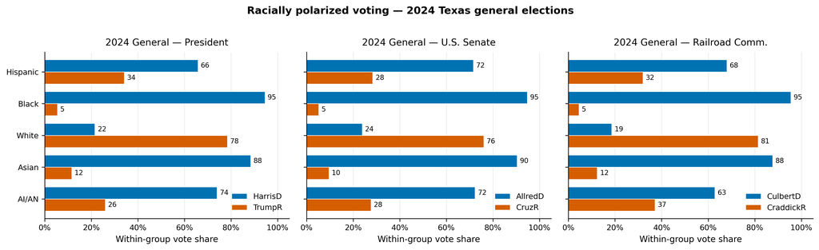

Racially polarized voting estimates from the 2024 Texas general elections, by racial group and candidate.

*Figure 1: Racially polarized voting estimates from the 2024 Texas general elections, by racial group and candidate.*

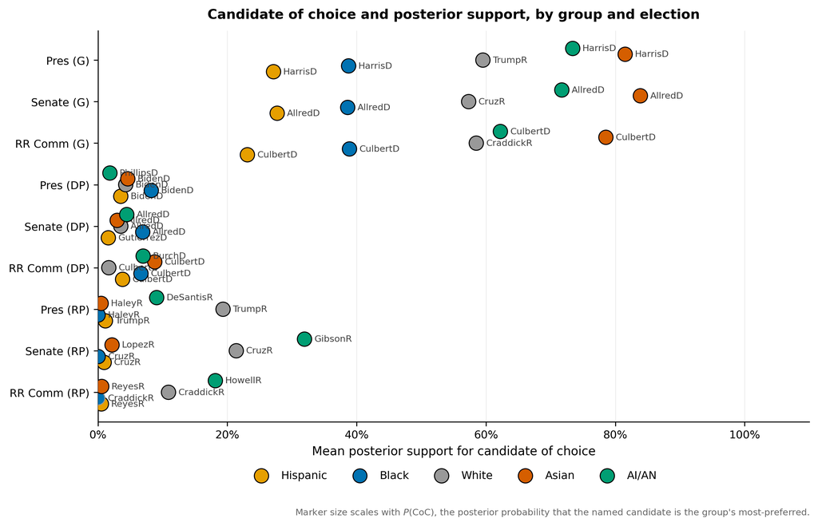

Mean posterior support for each racial group’s preferred candidate across the 2024 Texas statewide elections.

*Figure 2: Mean posterior support for each racial group’s preferred candidate across the 2024 Texas statewide elections. Each dot represents a (group, election) pair, positioned at the share of group CVAP supporting the named candidate. Primary supports are systematically low because the CVAP-based denominator includes the large majority of CVAP that abstains in primary elections.*

## 5.3 Ensemble Generation and Statistical Comparison Layer Implementation

The results in this section are obtained by applying the framework described in Section 4. To reiterate Section 4, the data engineering layer constructs precinct-level demographic and election inputs; the ecological inference layer estimates racial voting behavior and calibrated district-level win probabilities; and the ensemble layer generates legally constrained alternative plans and scores each plan using the minority-opportunity functionals. The enacted Texas plan is then compared to the Besag–Clifford spoke plans. If the enacted plan lies in the extreme lower tail of the resulting null distribution, this indicates that it provides less minority electoral opportunity than would be expected under the neutral comparison process.

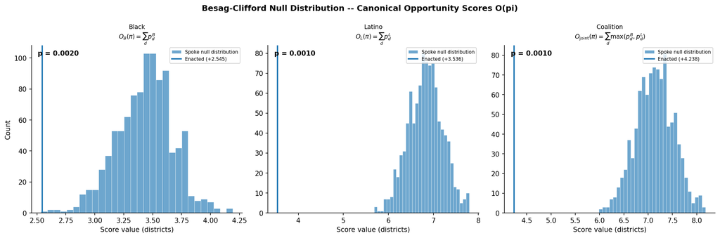

Besag–Clifford null distributions of the canonical minority opportunity functional.

*Figure 3: Besag–Clifford null distributions of the canonical minority opportunity functional. Panels show opportunity scores for Black voters, Latino voters, and the Black-Latino best-group functional. The enacted plan, denoted by the blue vertical line, lies in the lower tail of each distribution.*

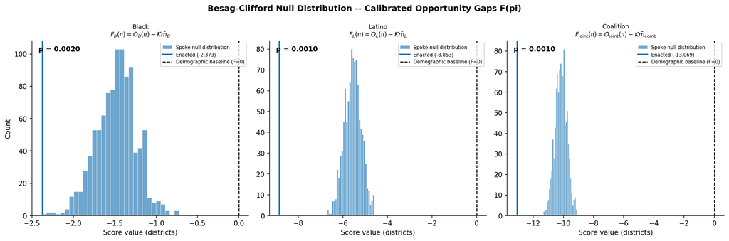

Besag–Clifford null distributions of the diversity-calibrated minority opportunity functional.

*Figure 4: Besag–Clifford null distributions of the diversity-calibrated minority opportunity functional. The histograms depict 1,000 spoke plans for Black, Latino, and best-group opportunity, respectively. The enacted Texas congressional map, denoted by the blue vertical line, lies in the lower tail of each distribution, with especially extreme results for Latino and best-group opportunity.*

[output not shown]

*Table 4: Comparison of enacted plan scores to ensemble distribution summaries.*

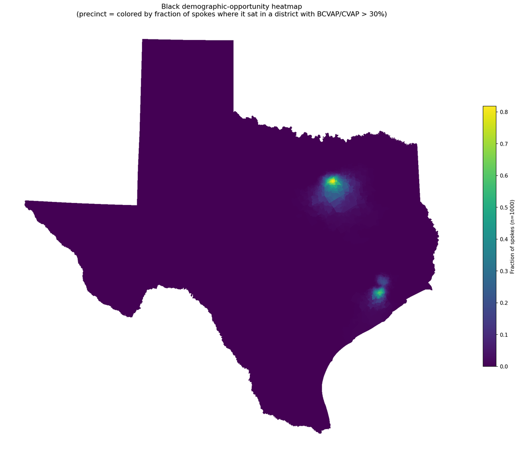

Heatmap depicting minority opportunity for Black voters.

*Figure 5: Heatmap depicting minority opportunity for Black voters. Each precinct is shaded by the fraction of the 1,000 Besag–Clifford spoke plans in which it was assigned to a district with a Black citizen voting-age population (BCVAP) greater than 30%. Two compact regions of Black opportunity emerge: the Dallas–Fort Worth metroplex (northern hotspot) and greater Houston (southeastern hotspot).*

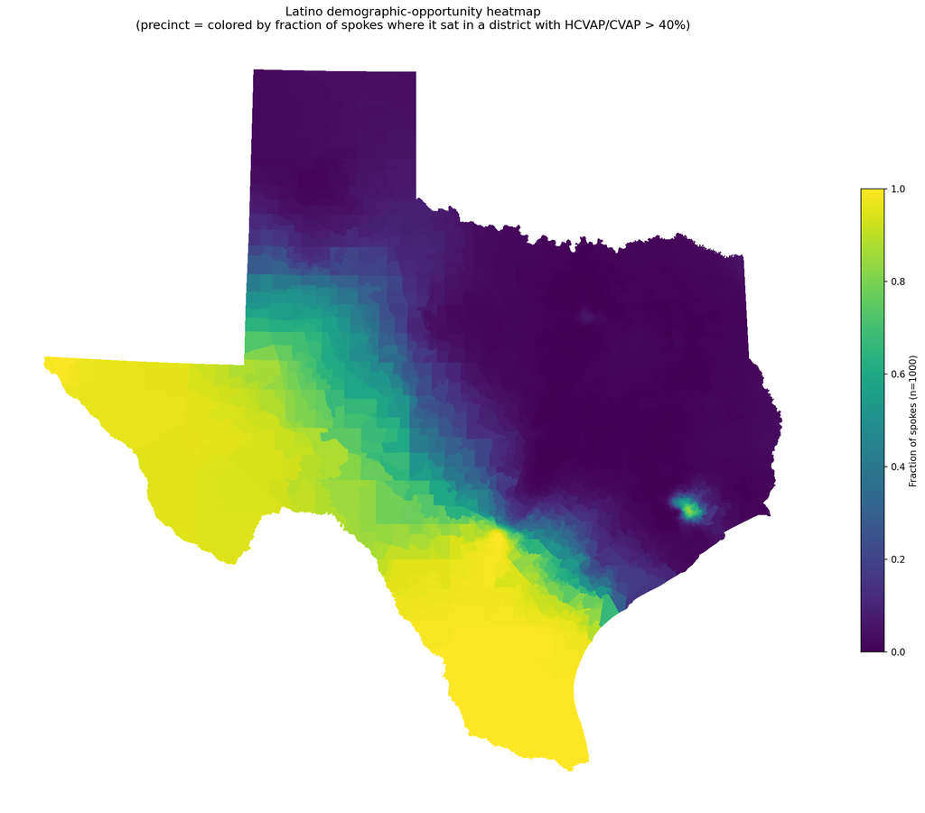

Heatmap depicting minority opportunity for Latino voters.

*Figure 6: Heatmap depicting minority opportunity for Latino voters. Each precinct is shaded by the fraction of the 1,000 Besag–Clifford spoke plans in which it was assigned to a district with a Hispanic citizen voting-age population (HCVAP) greater than 40%. Latino opportunity is broad and largely contiguous, dominating the Rio Grande Valley, South Texas, the U.S.-Mexico border corridor, and El Paso/West Texas, with a secondary cluster in Houston.*

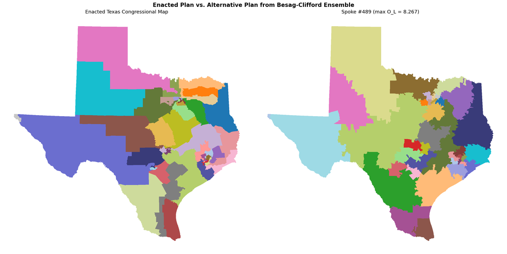

# 6 Discussion

This section interprets the Texas case-study findings, situates them relative to prior work, and acknowledges the framework’s limitations.

The Texas case study in Section 5 was produced by applying the full framework of Section 4 - data engineering, ecological inference with uncertainty propagation, and Besag-Clifford ensemble inference - to the enacted PLANC2333 plan and 1,000 spoke alternatives generated under legal constraints. Across all three opportunity functionals (canonical $O_g$, diversity-calibrated $F_g$, and best-group $O_{\mathrm{joint}}$), the enacted plan falls in the extreme left tail of the null distribution for Black voters, Latino voters, and the Black-Latino coalition, with exact Besag–Clifford $p$-values at or near the resolution floor of $1/(M+1) \approx 10^{-3}$.

These findings are consistent with - and extend - the prior Texas analysis of Becker et al. (Becker et al. 2021), which used a thresholded effectiveness-score methodology to argue that the 2021 Texas congressional map underprovided Black and Latino opportunity districts relative to legally compliant alternatives. The framework in this paper differs from theirs in three concrete respects: the opportunity score is the expected-count functional $O_g(\pi) = \sum_d p^g_d(\pi)$ rather than a thresholded indicator (Section 4.3.4); posterior EI uncertainty is propagated into the ensemble stage rather than collapsed to point estimates (Section 4.2); and the $p$-value is computed via Besag-Clifford exact inference rather than a long single-chain ReCom run (Section 4.4). The fact that the qualitative conclusion of dilution survives all three of these methodological changes - moving from threshold to expected count, from point estimates to uncertainty propagation, and from asymptotic to exact inference - strengthens the evidence that the observed dilution is a property of the plan rather than an artifact of any one scoring or inferential choice.

The results suggest that the observed dilution is not merely an artifact of a single scoring rule or a single election outcome. Rather, the enacted plan appears systematically atypical relative to legally constrained alternative district plans generated under the neutral baseline distribution.

## 6.1 Limitations

Several limitations should be acknowledged.

First, EI remains sensitive to model specification and aggregate assumptions. Posterior estimates may vary under alternative EI formulations.

Another limitation already mentioned in Section 2.1 is that the discounting method used for estimating census-block-level CVAP rates applies a “crude fix,” and a more sophisticated estimation method needs to be developed to address this.

Additionally, the framework assumes that statewide election behavior provides a meaningful proxy for voting behavior in congressional elections. This assumption is standard in redistricting analysis because statewide elections permit apples-to-apples comparisons across geographic regions, but it nevertheless abstracts away candidate-specific local dynamics.

Next, although the Besag-Clifford construction eliminates the need for convergence-to-stationarity assumptions, the resulting inference remains conditional on the chosen null distribution and legal constraint set. Different compactness thresholds, county-splitting tolerances, or demographic constraints may induce different baseline ensembles.

Finally, the framework is extremely computationally intensive. The EI layer took approximately 11 days to run (it was split in half to run simultaneously on Google Colab Pro+ and a workstation with an NVIDIA RTX 4080 Super). Running statewide EI, generating large constrained ReCom ensembles, and propagating posterior uncertainty jointly require substantial compute resources and data engineering effort.

These limitations should be considered when interpreting results. Future work should investigate scalable approximation methods and distributed implementations.

## 6.2 Future Work

Several extensions of the framework remain open for future research.

Future implementations should incorporate much larger election inventories spanning multiple election cycles (ten years’ worth, as suggested above). This would improve stability of EI estimates and reduce sensitivity to single-election effects.

Future work could explore alternative EI formulations, including hierarchical Bayesian models with spatial dependence or turnout-adjusted preference estimation.

Additional legal and geographic constraints could be incorporated into the ensemble-generation stage, including municipality preservation, communities of interest, incumbent protection, and partisan fairness criteria.

Although this paper focuses on Texas congressional districts, the framework is intentionally modular and portable. Future work should evaluate the framework across multiple states and redistricting contexts, including state legislative plans.

Finally, future research could investigate theoretical properties of opportunity functionals beyond the expected-count interpretation adopted here, including nonlinear utility formulations and coalition-sensitive opportunity measures. As newer ReCom successors with stronger theoretical properties - such as the Marked Edge Walk, Cycle Walk, and Balanced Up-Down walk - mature, swapping the ensemble-generation layer to use them would be a natural extension.

# 7 Conclusion

The paper’s central claim is that $\S$ 2 VRA analysis can be made more transparent by integrating data engineering, ecological inference, ensemble generation, and exact finite-sample inference into a single modular workflow.

This paper introduced a modular computational framework for $\S$ 2 VRA analysis integrating data engineering, ecological inference, ensemble generation, and exact inferential testing into a unified pipeline. The framework propagates posterior EI uncertainty through plan-level opportunity scoring and leverages the Besag-Clifford parallel construction to obtain exact finite-sample $p$-values without requiring convergence-to-stationarity assumptions.

The Texas case study illustrates how the framework can identify enacted district plans that systematically underperform neutral alternatives with respect to minority electoral opportunity. More broadly, the framework demonstrates how modern computational statistics, probabilistic modeling, and redistricting simulation can be combined into a coherent methodology for quantitative voting-rights analysis.

# Acknowledgements

I am indebted to the SoReMo Initiative at my home institution, Illinois Institute of Technology, for funding my research. Dr. Sonja Petrović, founder of the SoReMo Initiative, has provided invaluable statistical insights. Dr. Robert Ellis, my advisor, has provided candid and thorough feedback throughout the formulation of this paper. Dr. Shahrzad (Sara) Jamshidi, my former statistical learning and Bayesian statistics professor, was instrumental in helping me get this project off the ground. And since I first started this project, my mentor, Dr. Tianxiang Lu, has been providing astute code reviews and guidance. Dr. Ouassima Markouh wrote the first implementation of the data engineering pipeline in the early stages of the project. And Alaittin Kirtisoglu provided detailed feedback on the mixing-time literature.

# License

The author retains copyright of their work and reserves the right to submit to other journals.

Akitaya, Hugo A., Sarah Cannon, Gregory Herschlag, Gabe Schoenbach, Kristopher Tapp, and Jamie Tucker-Foltz. 2026. *The Balanced up-down Walk*. https://doi.org/10.48550/arXiv.2602.11993.

Barber, Rina Foygel, and Lucas Janson. 2022. “Testing Goodness-of-Fit and Conditional Independence with Approximate Co-Sufficient Sampling.” *The Annals of Statistics* 50 (5): 2514–44. https://doi.org/10.1214/22-AOS2187.

Becker, Ari, Moon Duchin, Dustin Gold, and Samuel Hirsch. 2021. “Computational Redistricting and the Voting Rights Act.” *Election Law Journal: Rules, Politics, and Policy* 20 (4): 407–41. https://doi.org/10.1089/elj.2020.0704.

Besag, Julian, and Peter Clifford. 1989. “Generalized Monte Carlo Significance Tests.” *Biometrika* 76 (4): 633–42.

Cain, Bruce E. 1985. “Assessing the Partisan Effects of Redistricting.” *American Political Science Review* 79 (2): 320–33.

Cannon, Sarah, Moon Duchin, Dana Randall, and Parker Rule. 2022. “Spanning Trees and Redistricting: New Methods for Sampling and Validation.” *arXiv Preprint arXiv:2210.01401*, ahead of print. https://doi.org/10.48550/arXiv.2210.01401.

Cannon, Sarah, Alex Goldbloom-Helzner, Varun Gupta, J. N. Matthews, and Binod Suwal. 2022. “Voting Rights, Markov Chains, and Optimization by Short Bursts.” *arXiv Preprint arXiv:2011.02288*. https://arxiv.org/abs/2011.02288.

Cannon, Sarah, Wesley Pegden, and Jamie Tucker-Foltz. 2025. “Sampling Tree-Weighted Partitions Without Sampling Trees.” *arXiv Preprint arXiv:2508.11130*, ahead of print. https://doi.org/10.48550/arXiv.2508.11130.

Chen, Jowei, and Jonathan Rodden. 2013. “Unintentional Gerrymandering: Political Geography and Electoral Bias in Legislatures.” *Quarterly Journal of Political Science* 8 (3): 239–69. https://doi.org/10.1561/100.00012033.

DeFord, Daryl R., Gregory Herschlag, and Jonathan C. Mattingly. 2025. *A Cycle Walk for Sampling Measures on Spanning Forests for Redistricting*. https://arxiv.org/abs/2509.08629.

DeFord, Daryl, Moon Duchin, and Justin Solomon. 2021. “Recombination: A Family of Markov Chains for Redistricting.” *Harvard Data Science Review* 3 (1). https://doi.org/10.1162/99608f92.4c6d50b1.

Donnay, M. and Duchin, M. and Rock, P. n.d. *Conventions for Constructing Demographic Categories*. {https://mggg.org/vap-cvap}.

Duchin, M., and O. Walch, eds. 2022. *Political Geometry: Rethinking Redistricting in the US with Math, Law, and Everything in Between*. Birkhäuser.

Eckman, Sarah J., and L. Paige Whitaker. 2025. *Mid-Decade Congressional Redistricting: Key Issues*. CRS In Focus No. IF13082. Congressional Research Service. https://www.congress.gov/crs-product/IF13082.

Freedman, David A. 1999. “Ecological Regression and Voting Rights.” *Evaluation Review* 23 (4): 328–42. https://doi.org/10.1177/0193841X9902300401.

Goodman, J. David. 2025. “Texas Republicans Pass New Congressional Map Aimed at Expanding House Majority.” *The New York Times*.

Hoerl, Arthur E., and Robert W. Kennard. 1970. “Ridge Regression: Biased Estimation for Nonorthogonal Problems.” *Technometrics* 12 (1): 55–67. https://doi.org/10.1080/00401706.1970.10488634.

King, Gary. 1997. *A Solution to the Ecological Inference Problem*. Princeton University Press.

King, Gary, Ori Rosen, and Martin A. Tanner. 1999. “Binomial-Beta Hierarchical Models for Ecological Inference.” *Sociological Methods & Research* 28 (1): 61–90.

King, G., O. Rosen, and M. Tanner. 2004. *Ecological Inference: New Methodological Strategies*. Cambridge University Press.

Levin, David A., Yuval Peres, and Elizabeth L. Wilmer. 2009. *Markov Chains and Mixing Times*. American Mathematical Society.

McWhorter, Atticus, and Daryl DeFord. 2025. *The Marked Edge Walk: A Novel MCMC Algorithm for Sampling of Graph Partitions*. https://arxiv.org/abs/2510.17714.

Platt, John C. 1999. “Probabilistic Outputs for Support Vector Machines and Comparisons to Regularized Likelihood Methods.” In *Advances in Large Margin Classifiers*, edited by Alexander J. Smola, Peter Bartlett, Bernhard Schölkopf, and Dale Schuurmans. MIT Press.

Rosen, Ori, Wenxin Jiang, Gary King, and Martin A. Tanner. 2001. “Bayesian and Frequentist Inference for Ecological Inference: The r $\times$ c Case.” *Statistica Neerlandica* 55 (2): 134–56. https://doi.org/10.1111/1467-9574.00163.

Sauer, SO. 1992. “Geography and the Gerrymander.” *American Economic Review* 82 (2): 94–98.

Supreme Court of the United States. 1986. *Thornburg v. Gingles*. 478 U.S. 30.

Supreme Court of the United States. 1993. *Shaw v. Reno*.

Supreme Court of the United States. 1995. *Miller v. Johnson*.

Supreme Court of the United States. 1996. *Bush v. Vera*.

Supreme Court of the United States. 2017a. *Bethune-Hill v. Virginia State Board of Elections, 580 U.S. 178*.

Supreme Court of the United States. 2017b. *Cooper v. Harris, 581 U.S. 285*.

Supreme Court of the United States. 2018. *Abbott v. Perez*.

Supreme Court of the United States. 2023. *Allen v. Milligan*. 599 U.S. 1.

Supreme Court of the United States. 2024. *Alexander v. South Carolina State Conference of the NAACP, 602 U.S.*

Supreme Court of the United States. 2025a. *League of United Latin American Citizens v. Abbott*.

Supreme Court of the United States. 2025b. *Order Granting Stay, LULAC v. Abbott*.

Texas Legislative Council. 2025. *PlanC2333: Texas Congressional Districts*. Capitol Data Portal. https://data.capitol.texas.gov/dataset/planc2333.

Texas State Conference of the NAACP. 2025. *Appendix to Respondent Texas NAACP’s Response in Opposition to Emergency Application for Stay Pending Appeal*. Supreme Court of the United States, No. 25A608. https://www.supremecourt.gov/DocketPDF/25/25A608/385657/20251124154506057_No.%2025A608%20TXNAACP%20Appendix.pdf.

United States. 1787. *Constitution of the United States, Article i, Section 2*.

United States Congress. 1868. *U.S. Constitution, Amendment XIV, Section 1*.

United States Congress. 1965. *Voting Rights Act of 1965, Section 2*.

U.S. Supreme Court. 2019. *Rucho v. Common Cause*. [Https://supreme.justia.com/cases/federal/us/588/18-422/](https://supreme.justia.com/cases/federal/us/588/18-422/).

Valelly, Richard M. 2004. *The Two Reconstructions: The Struggle for Black Enfranchisement*. University of Chicago Press.

Voting Rights Lab. 2026. “An Emerging Trend: Mid-Decade Redistricting.” Voting Rights Lab, May 26. https://votingrightslab.org/2026/05/26/an-emerging-trend-mid-decade-redistricting/.

[^1]: Contact the author.